# RR Peer Assignment 1

Kelsey Fecho

Thursday, September 10, 2015

## Load the Data

Set the working directory to the folder where out data set is saved. To do so, save the folder location into the dir variable, and call the setwd argument as below.

```r
dir <- c("C:/Users/kfecho/Documents/Training/Coursera/Reproducible Research/RepData_PeerAssessment1")
setwd(dir)
```

Now that the program knows where to look, use read.csv to load the data set into R. We’ll also save the file into a variable called “activity” so we can use it easily later.

```r
activity <- read.csv(file="activity.csv", header=TRUE)
```

## What is the mean total number of steps taken per day?

For this part of the assignment, the data needs to not include any missing values, entered as “NA”. Create a subset of only complete rows with the na.omit function.

```r
complete <- na.omit(activity)
```

Aggregates the number of steps for each day of the recorded data. The data covers 53 days, so let’s add a check at the end to make sure we have 53 records.

```r
dailysteps <- aggregate(steps ~ date, data=complete, sum)
dim(dailysteps)
```

```
## [1] 53  2
```

Now that we have the data aggregated as necessary, call the desired data, in this case steps, into the hist() function.

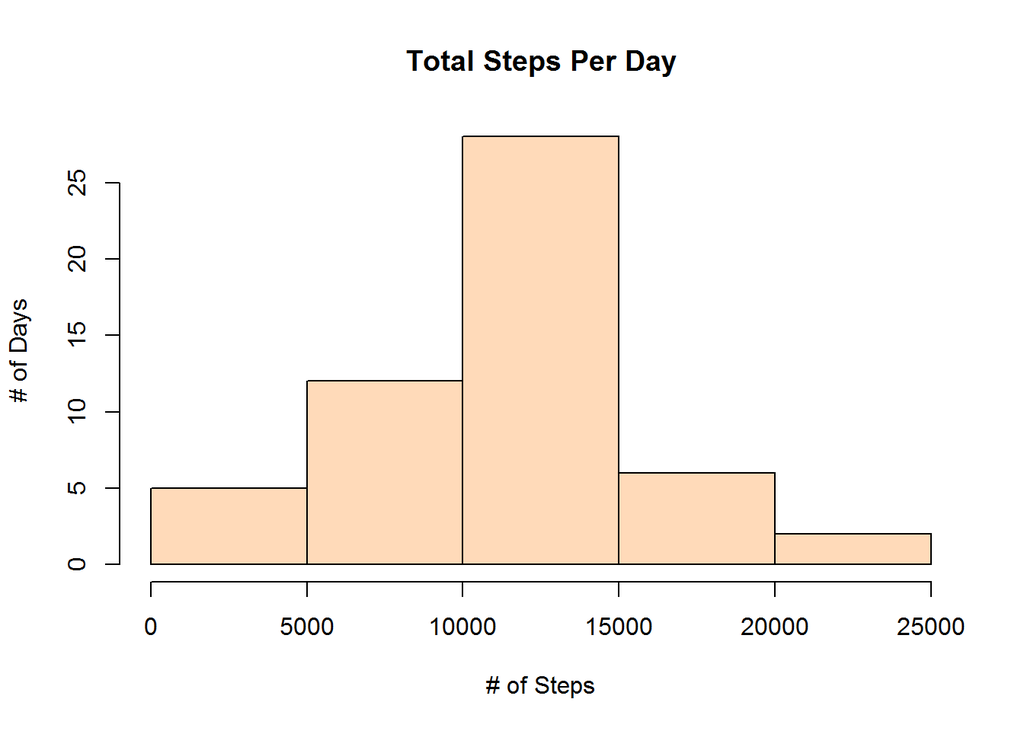

```r
hist(dailysteps$steps, col="peachpuff", main="Total Steps Per Day", xlab="# of Steps", ylab="# of Days")
```

Mean and Median are easy calculations to make in R, and are a good way to exploratorily analyze data quickly.

```r
mean(dailysteps$steps)
```

```
## [1] 10766.19
```

```r
median(dailysteps$steps)
```

```
## [1] 10765
```

## What is the average daily activity pattern?

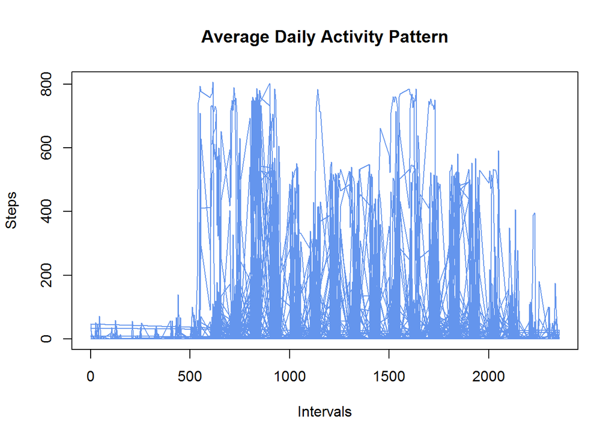

```r
plot(complete$interval, complete$steps, type = "l", col="cornflowerblue", main = "Average Daily Activity Pattern", xlab="Intervals", ylab="Steps")
```

```r
max(complete$steps)
```

```
## [1] 806
```

```r
most <- complete[complete$steps=="806",]
most
```

```
##       steps       date interval
## 16492   806 2012-11-27      615
```

## Imputing Missing Values

Back with our original data set, “activity”, we’ll need to figure out how to populate NA values logically. First, let’s **calculate the numbers of rows containing “NA”** in the original data set.

```r
missing <- activity[activity$step == "NA",]
dim(missing)
```

```
## [1] 2304    3
```

```r
meansteps <- aggregate(steps~interval, data=complete,mean)
head(meansteps)
```

```
##   interval     steps
## 1        0 1.7169811
## 2        5 0.3396226
## 3       10 0.1320755
## 4       15 0.1509434
## 5       20 0.0754717
## 6       25 2.0943396
```

```r
dim(meansteps)
```

```
## [1] 288   2
```

Now, I will merge the original data set with the mean steps data set by interval and check my output with the head() function.

```r
merge <- merge(activity, meansteps, by="interval")
head(merge)
```

```
##   interval steps.x       date  steps.y
## 1        0      NA 2012-10-01 1.716981
## 2        0       0 2012-11-23 1.716981
## 3        0       0 2012-10-28 1.716981
## 4        0       0 2012-11-06 1.716981
## 5        0       0 2012-11-24 1.716981
## 6        0       0 2012-11-15 1.716981
```

Now that we have both NA values and intended values in the same data set, I will use a for loop to move mean values to the step column only when the step column equals “NA”. Again, I will use head() to check my output. Only the rows that were originally “NA” should have new values.

```r
nrow(merge)
```

```
## [1] 17568
```

```r
for (i in 1:nrow(merge)){
  if(is.na(merge[i,2])){merge[i,2]=merge[i,4]}
}
head(merge)
```

```
##   interval  steps.x       date  steps.y
## 1        0 1.716981 2012-10-01 1.716981
## 2        0 0.000000 2012-11-23 1.716981
## 3        0 0.000000 2012-10-28 1.716981
## 4        0 0.000000 2012-11-06 1.716981
## 5        0 0.000000 2012-11-24 1.716981
## 6        0 0.000000 2012-11-15 1.716981
```

```r
final <- merge[,1:3]
head(final)
```

```
##   interval  steps.x       date
## 1        0 1.716981 2012-10-01
## 2        0 0.000000 2012-11-23
## 3        0 0.000000 2012-10-28
## 4        0 0.000000 2012-11-06
## 5        0 0.000000 2012-11-24
## 6        0 0.000000 2012-11-15
```

Repeating aggregation logic from before, we need to aggregate the number of steps per day now that all NA values have been imputed with new values, make a histogram, and calculate the mean and median of our new data.

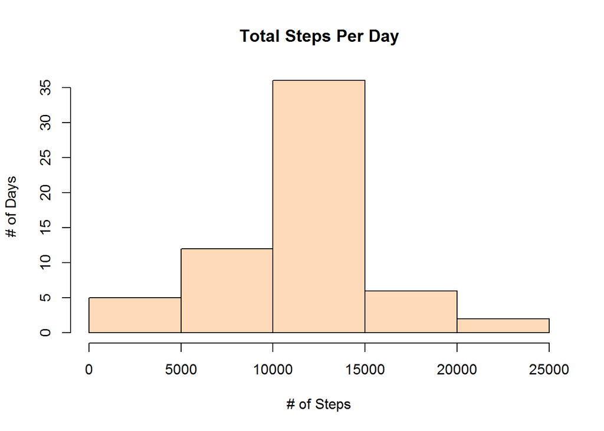

```r
finaldailysteps <- aggregate(steps.x~date, data=final, sum)
hist(finaldailysteps$steps.x, col="peachpuff", main="Total Steps Per Day", xlab="# of Steps", ylab="# of Days")
```

```r
mean(finaldailysteps$steps.x)
```

```
## [1] 10766.19
```

```r
median(finaldailysteps$steps.x)
```

```
## [1] 10766.19
```

We can see now that the mean has not changed from before. This is because we used interval **means** to impute NA values. However, the median has now increased slightly and is now equal with the mean. This is because by filling in values greater than 0 where none have previously existed increased the number of total steps. It is only logical, then, that the middle number of that data set should increase.